# Final Project (Evelin)

Evelin Garcia

11/24/2021

**This dataset consists of the following variables:**

- `Title`: character variable of movie title
- `Year`: Release year of the film
- `Age`: Intended age group for the movie’s audience (ex: 17+ means 17 year olds are the youngest target audience)
- `IMDb`: IMDb rating for the movie, out of a scale of 10
- `Rotten Tomatoes`: Rotten Tomatoes rating for the movie, out of a scale of 100
- `Netflix`, `Hulu`, `Prime Video`, `Disney+`: Indicator variables that inform us about which platform the movie is found on
- `Directors`: character variable listing the movie director(s)
- `Genres`: character variable listing the movie genres
- `Country`: character variable indicating which countries the movie is available on for the respective streaming platform
- `Language`: character variable listing the languages in which the movie is available on the streaming platform
- `Runtime`: numeric variable providing movie run-time in minutes

## Importing the data

```r
data <- read.csv("MoviesOnStreamingPlatforms_updated.csv")
head(data)
```

```
##   X ID                                    Title Year Age   IMDb Rotten.Tomatoes
## 1 0  1                             The Irishman 2019 18+ 7.8/10          98/100
## 2 1  2                                   Dangal 2016  7+ 8.4/10          97/100
## 3 2  3 David Attenborough: A Life on Our Planet 2020  7+ 9.0/10          95/100
## 4 3  4        Lagaan: Once Upon a Time in India 2001  7+ 8.1/10          94/100
## 5 4  5                                     Roma 2018 18+ 7.7/10          94/100
## 6 5  6        To All the Boys I've Loved Before 2018 13+ 7.1/10          94/100
##   Netflix Hulu Prime.Video Disney. Type
## 1       1    0           0       0    0
## 2       1    0           0       0    0
## 3       1    0           0       0    0
## 4       1    0           0       0    0
## 5       1    0           0       0    0
## 6       1    0           0       0    0
##                                           Directors
```

[output cut: 27 more lines]

## Data Exploration

```r
# Determine variable classes
  lapply(data, class)
```

```
## $X
## [1] "integer"
##
## $ID
## [1] "integer"
##
## $Title
## [1] "character"
##
## $Year
## [1] "integer"
##
## $Age
## [1] "character"
##
## $IMDb
## [1] "character"
##
## $Rotten.Tomatoes
## [1] "character"
##
## $Netflix
## [1] "integer"
##
## $Hulu
## [1] "integer"
##
## $Prime.Video
## [1] "integer"
##
## $Disney.
## [1] "integer"
##
## $Type
## [1] "integer"
##
## $Directors
## [1] "character"
##
## $Genres
## [1] "character"
##
## $Country
## [1] "character"
##
## $Language
## [1] "character"
##
## $Runtime
## [1] "numeric"
```

Exploring the distribution of movie releases over time

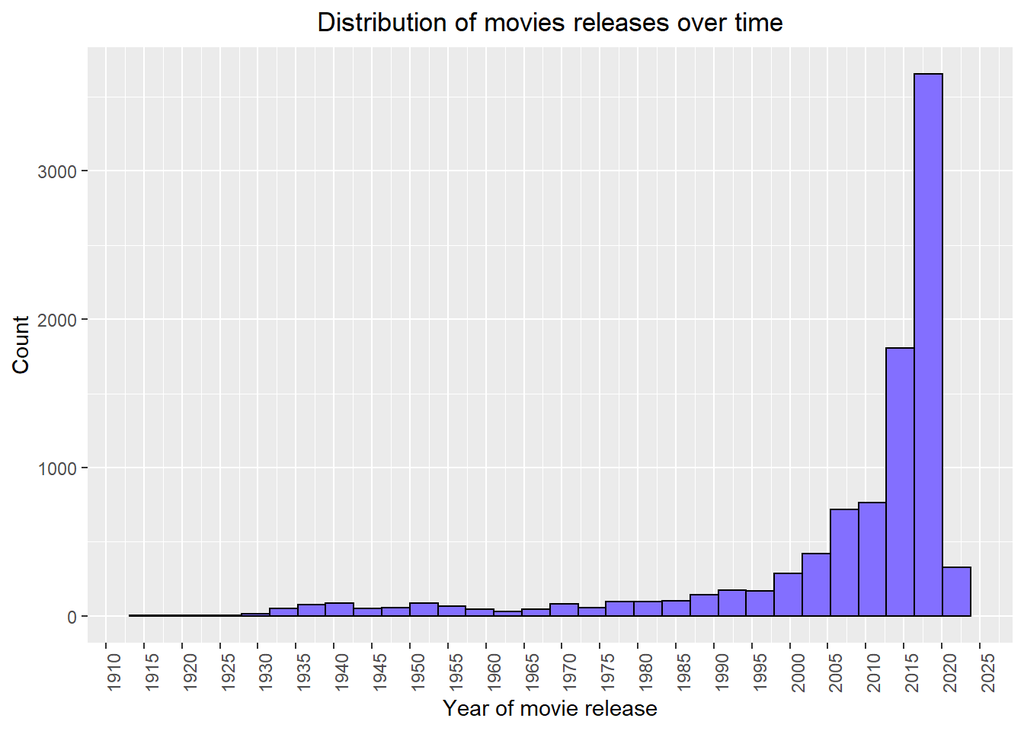

```r
# Exploring the distribution of movie releases over time
  data %>% ggplot(aes(x = Year)) +
           geom_histogram(color = "black", fill = "slateblue1") +
           scale_x_continuous(breaks=seq(0,2025,5))+
           theme(axis.text.x = element_text(angle = 90, hjust = 1, size=9))+
           theme(plot.title = element_text(hjust=0.5))+
           ylab("Count") + xlab("Year of movie release") +
           ggtitle("Distribution of movies releases over time")
```

Explore the distribution of movie release years by streaming platform

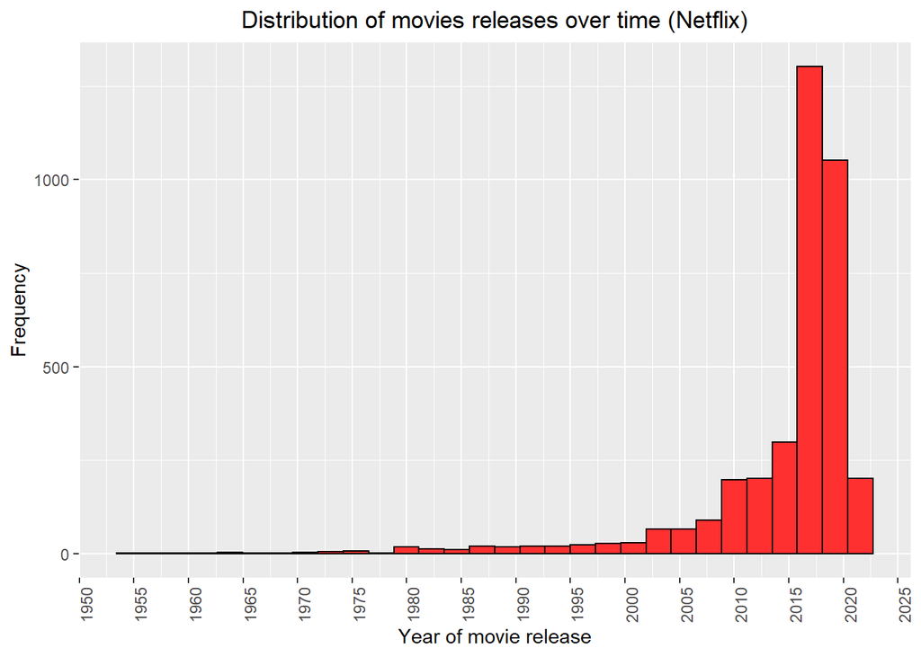

```r
# Explore the distribution of movie release years by streaming platform

  #Netflix
    data %>% filter(Netflix == 1) %>%
               ggplot(aes(x = Year)) +
               geom_histogram(color = "black", fill = "firebrick1") +
               scale_x_continuous(breaks=seq(0,2025,5))+
               theme(axis.text.x = element_text(angle = 90, hjust = 1, size=9))+
               theme(plot.title = element_text(hjust=0.5))+
               ylab("Frequency") + xlab("Year of movie release") +
               ggtitle("Distribution of movies releases over time (Netflix)")
```

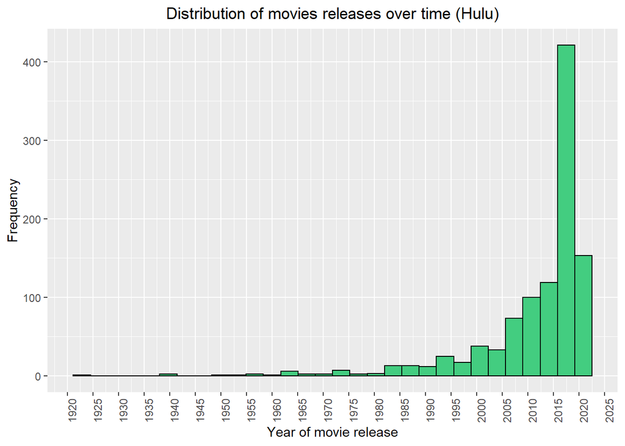

```r
  #Hulu
    data %>% filter(Hulu == 1) %>%
               ggplot(aes(x = Year)) +
               geom_histogram(color = "black", fill = "seagreen3") +
               scale_x_continuous(breaks=seq(0,2025,5))+
               theme(axis.text.x = element_text(angle = 90, hjust = 1, size=9))+
               theme(plot.title = element_text(hjust=0.5))+
               ylab("Frequency") + xlab("Year of movie release") +
               ggtitle("Distribution of movies releases over time (Hulu)")
```

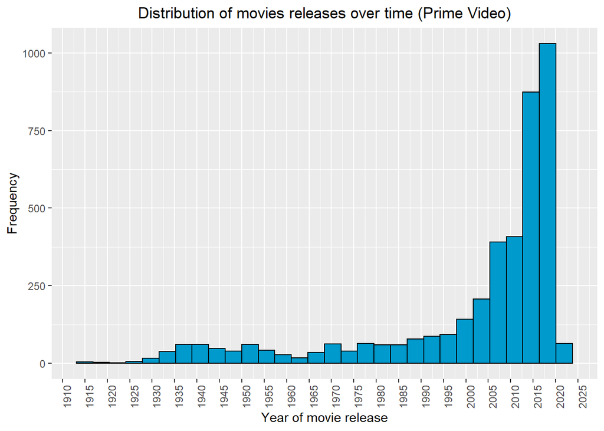

```r
  #Prime Video
    data %>% filter(Prime.Video == 1) %>%
               ggplot(aes(x = Year)) +
               geom_histogram(color = "black", fill = "deepskyblue3") +
               scale_x_continuous(breaks=seq(0,2025,5))+
               theme(axis.text.x = element_text(angle = 90, hjust = 1, size=9))+
               theme(plot.title = element_text(hjust=0.5))+
               ylab("Frequency") + xlab("Year of movie release") +
               ggtitle("Distribution of movies releases over time (Prime Video)")
```

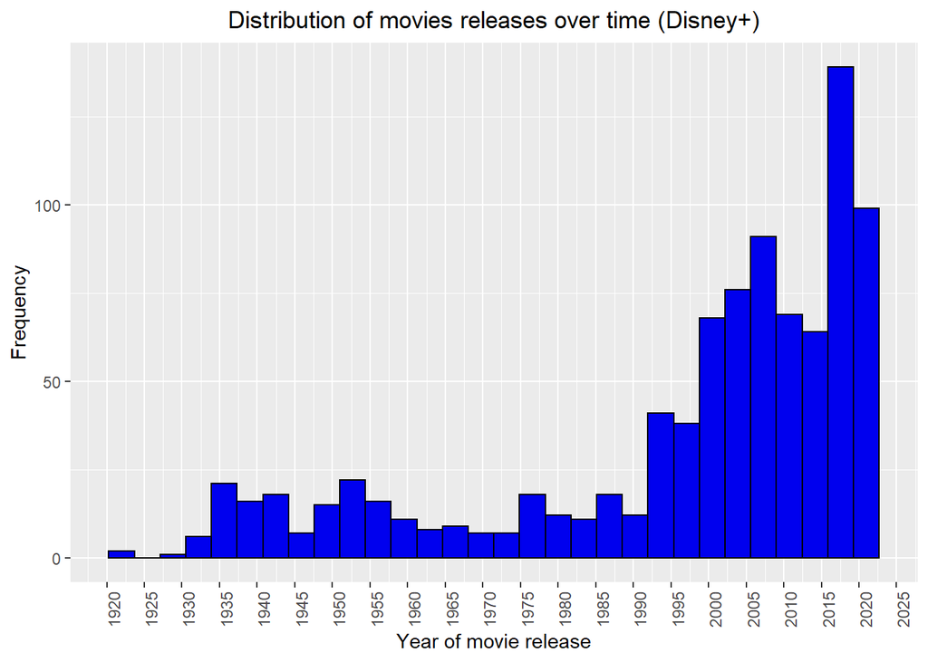

```r
  #Disney+
    data %>% filter(Disney. == 1) %>%
               ggplot(aes(x = Year)) +
               geom_histogram(color = "black", fill = "blue2") +
               scale_x_continuous(breaks=seq(0,2025,5))+
               theme(axis.text.x = element_text(angle = 90, hjust = 1, size=9))+
               theme(plot.title = element_text(hjust=0.5))+
               ylab("Frequency") + xlab("Year of movie release") +
               ggtitle("Distribution of movies releases over time (Disney+)")
```

Exploring the distribution of movie run-time

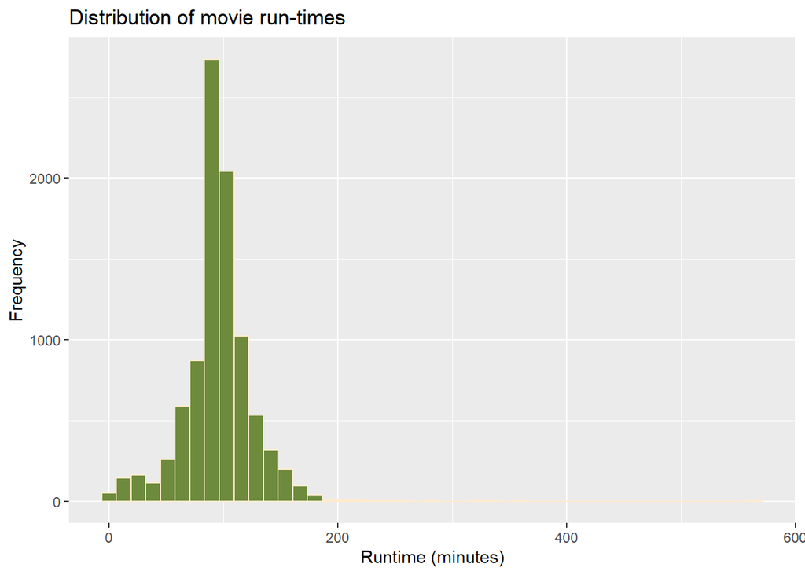

```r
# Exploring the distribution of movie run-time
  data %>% ggplot(aes(x=Runtime)) +
           geom_histogram(bins=45, color="blanchedalmond", fill="darkolivegreen4")+
           labs(x="Runtime (minutes)", y="Frequency",
                title="Distribution of movie run-times")
```

## Text Analysis

Because we want to be able to examine country-specific phenomena in the data, we need to change how our `Country` variable is organized. The variable originally contains several countries within a single cell, with country names separated by a comma. Below, we split the column into several country columns, then tidy the data by creating a single country column that contains one country observation per cell.

```r
# String processing for Country
  data <- data %>%
  #Using the 'separate' function so each country is in its own column
          separate(Country, c("Country 1", "Country 2", "Country 3", "Country 4",
                              "Country 5", "Country 6", "Country 7", "Country 8",
                              "Country 9", "Country 10", "Country 11", "Country 12",
                              "Country 13", "Country 14", "Country 15"), sep=",",
                              remove=TRUE, extra="merge") %>%
  #Using pivot_longer (instead of gather) to create one column for countries wherein     there's only one observation per cell
          pivot_longer(c(`Country 1`, `Country 2`, `Country 3`, `Country 4`,
                         `Country 5`, `Country 6`, `Country 7`, `Country 8`,
                         `Country 10`, `Country 11`, `Country 12`,
                         `Country 13`, `Country 14`, `Country 15`),
                      names_to="country_num", values_to="countries",
                      values_drop_na=TRUE) #dropping rows with NA values in new column
```

We find the same issue with `Genre` and `Language`, so we process these the same way we did for Country above:

```r
# String processing for Genre
  data <- data %>%
 #Using separate function so each genre is in it's own column
          separate(Genres, c("Genre 1", "Genre 2", "Genre 3", "Genre 4", "Genre 5",
                             "Genre 6", "Genre 7", "Genre 8", "Genre 9"), sep=",",
                             remove=TRUE, extra="merge") %>%
 #Using pivot_longer to create one column for genres with only 1 observation per cell
          pivot_longer(c(`Genre 1`, `Genre 2`, `Genre 3`, `Genre 4`, `Genre 5`,
                         `Genre 6`, `Genre 7`, `Genre 8`, `Genre 9`),
                       names_to="genre_num", values_to="genres",
                       values_drop_na=TRUE) #dropping NA values
# String processing for Language
  data <- data %>%
  #Using separate function so each language is in its own column
          separate(Language, c("Language 1", "Language 2", "Language 3", "Language 4",
                             "Language 5", "Language 6", "Language 7", "Language 8",
                             "Language 9", "Language 10", "Language 11",
                             "Language 12", "Language 13", "Language 14"), sep=",",
                             remove=TRUE, extra="merge") %>%
 #Using pivot_longer to create one languages column with only 1 observation per cell
          pivot_longer(c(`Language 1`, `Language 2`, `Language 3`, `Language 4`,
                         `Language 5`, `Language 6`, `Language 7`, `Language 8`,
                         `Language 9`, `Language 10`, `Language 11`, `Language 12`,
                         `Language 13`, `Language 14`), names_to = "lang_num",
                       values_to = "languages", values_drop_na=TRUE) #dropping NAs
```

Since we may want to explore trends and distributions in ratings, we want both of the ratings variables to be numeric, so we must drop the “/10” and “/100” from each string:

```r
# IMDb ratings
  #Start by separating the rating into two columns (numerator and denominator), then     drop the denominator column
   data <- data %>%
           separate(IMDb, c("IMDb", "IMDb_denom"), sep="/", remove=TRUE) %>%
           subset(select= -IMDb_denom)
  #Convert new IMDb from character to numeric
   data$IMDb <- as.numeric(data$IMDb)

# Rotten Tomatoes ratings
  #Start by separating the rating into two columns (numerator and denominator), then     drop the denominator column
   data <- data %>%
           separate(`Rotten.Tomatoes`, c("rotten_tom", "tom_denom"), sep="/",
                     remove=TRUE) %>% subset(select= -tom_denom)
 #Convert new Rotten Tomatoes rating from character to numeric
  data$rotten_tom <- as.numeric(data$rotten_tom)
```

Some movies are available on more than one streaming platform. Since this may be of interest, we want to create a variable that lets us know how many platforms the movie is available on:

```r
# Create a new 'platforms' variable
  data$platforms <- rowSums(data[, c("Netflix", "Hulu", "Prime.Video", "Disney.")])
```

Now that our data are clean and formatted, we’ll export the df as a csv to share with group members:

```r
write.csv(data, "cleaned_data.csv")
```

## Machine Learning

Here we will build models to predict the outcome, ratings on Rotten Tomatoes. But first, we will perform some more data wrangling to prepare the data set for machine learning analyses.

First we will convert all categorical variables into factors (and not numeric)

```r
lapply(data, class)
```

```
## $X
## [1] "integer"
##
## $ID
## [1] "integer"
##
## $Title
## [1] "character"
##
## $Year
## [1] "integer"
##
## $Age
## [1] "character"
##
## $IMDb
## [1] "numeric"
##
## $rotten_tom
## [1] "numeric"
##
## $Netflix
## [1] "integer"
##
## $Hulu
## [1] "integer"
##
## $Prime.Video
## [1] "integer"
##
## $Disney.
## [1] "integer"
##
## $Type
## [1] "integer"
##
## $Directors
## [1] "character"
##
## $`Country 9`
```

[output cut: 10 more lines]

```
##
## $genre_num
## [1] "character"
##
## $genres
## [1] "character"
##
## $lang_num
## [1] "character"
##
## $languages
## [1] "character"
##
## $platforms
## [1] "numeric"
```

```r
data <- data %>% mutate(title = as.factor(Title),
                        countries = as.factor(countries),
                        genres = as.factor(genres),
                        languages = as.factor(languages),
                        platforms = as.factor(platforms)) %>%
                select(-"Country 9") %>%
                drop_na()

lapply(data, class)
```

```
## $X
## [1] "integer"
##
## $ID
## [1] "integer"
##
## $Title
## [1] "character"
##
## $Year
## [1] "integer"
##
## $Age
## [1] "character"
##
## $IMDb
## [1] "numeric"
##
## $rotten_tom
## [1] "numeric"
##
## $Netflix
## [1] "integer"
##
## $Hulu
## [1] "integer"
##
## $Prime.Video
## [1] "integer"
##
## $Disney.
## [1] "integer"
##
## $Type
## [1] "integer"
##
## $Directors
## [1] "character"
##
## $Runtime
```

[output cut: 10 more lines]

```
##
## $genres
## [1] "factor"
##
## $lang_num
## [1] "character"
##
## $languages
## [1] "factor"
##
## $platforms
## [1] "factor"
##
## $title
## [1] "factor"
```

Then we will create a new data frame called `new_df`with reshaped data.

```r
new_df <- data %>%
          group_by(title) %>%
          summarize(genres = n_distinct(genres),
                    countries = n_distinct(countries),
                    languages = n_distinct(languages),
                    runtime = Runtime[1],
                    ratings = rotten_tom[1],
                    platforms = n_distinct(platforms),
                    year = Year[1])


head(new_df)
```

```
## # A tibble: 6 x 8
##   title               genres countries languages runtime ratings platforms  year
##   <fct>                <int>     <int>     <int>   <dbl>   <dbl>     <int> <int>
## 1 '71                      5         1         1      99      71         1  2014
## 2 'Neath Brooklyn Br~      4         1         1      61      44         1  1942
## 3 'Twas the Night          2         1         1      84      45         1  2001
## 4 #Alive                   4         1         1      98      62         1  2020
## 5 #AnneFrank. Parall~      2         1         1      92      54         1  2019
## 6 #cats_the_mewvie         1         1         1      90      46         1  2020
```

Now, we will create training and test sets using a 70% training, 30% test set split. We will use the function, `stratified`, from the `splitstackshape` package to split the data. The `stratified` function samples the same percent of individuals from each class - in this case, `ratings`. Note: We are including `set.seed(1)` so we get the same train/test split and model predictions we do.

```r
# Rotten Tomatoes Training and Test Sets
  set.seed(1)
  x <- stratified(new_df, "ratings", 0.7, keep.rownames = TRUE)
  train_set <- x %>% dplyr::select(-rn)
  train_index <- as.numeric(x$rn)
  test_set <- new_df[-train_index,]

  dim(train_set)
```

```
## [1] 6361    8
```

```r
  dim(test_set)
```

```
## [1] 2723    8
```

# Random Forest Model

Using the `randomForest` function, we fit a Random Forest model to the training set that predicts `ratings` based on the following predictors: -`genres` -`countries` -`languages` -`runtime` -`platforms` -`year`

```r
set.seed(1)

# Fit the Random Forest model based on the selected predictors
  rf_fit <- randomForest(ratings ~ genres + countries + languages + runtime +
                           platforms + year, data = train_set, mtry=5)

  # Find the predicted ratings from model
  y_hat_rf = predict(rf_fit, newdata = test_set)
```

Gini Index Calculating variable importance using Gini index for the random forest model. *Based on this, run-time seems to be the most important predictor of rotten tomato ratings followed by year, genre, language, country, and platforms its available on.*

```r
variable_importance = importance(rf_fit)

variable_importance_survival =

  tibble(varb = rownames(variable_importance),

             Gini = variable_importance[,1])

variable_importance_survival %>%

  arrange(desc(Gini)) %>% head(8)
```

```
## # A tibble: 6 x 2
##   varb         Gini
##   <chr>       <dbl>
## 1 runtime   347254.
## 2 year      232682.
## 3 genres    109197.
## 4 languages  48475.
## 5 countries  48304.
## 6 platforms      0
```